# Introduction

This iPython notebook was written to explore the various different numerical methods for solving first-order ODEs. Three methods are explored: Euler's Methods, The Midpoint Method, and the Classical Runge-Kutta method. RMS error is explored for each method.

```python
import numpy as np
import matplotlib.pyplot as plt
from math import *
%matplotlib inline

plt.rc('text', usetex=True)      #Plots take longer but look nicer
plt.rc('font', family='serif')
```

## Euler's Method:

Basic method, using the Taylor Series to approximate $y(x)$ as a tangent line to the point $(x, y(x))$.

given $dy/dx = f(x,y)$, $\Delta{}y \approx f(x,y)\Delta{}x \implies y(x+h) \approx y(x) + h*f(x,y(x))$

```python
def eulers_method(f, x, y, h):
    """
    Given a function f, the current x and the current y, returns an approximation of y(x+h) using Euler's method
    assuming that dy/dx = f(x,y)
    """
    return y + h * f(x,y)
```

## Midpoint method:

Slightly more accurate than Euler's method, using the slope of the point $(x + h/2, y(x+h/2))$ (the midpoint of the interval) rather than $(x,y(x))$, as the midpoint better represents the averager slope on the interval $[x, x+h]$.

$y(x+h) \approx y(x) +h*f(x+h/2, y(x) + h/2*f(x,y))$

```python
def midpoint_method(f, x, y, h):
    """
    Given a function f, the current x and the current y, returns an approximation of y(x+h) using the Midpoint method
    assuming that dy/dx = f(x,y)
    """
    return y + h * f(x+h/2.,y + h/2. * f(x,y))
```

## Runge-Kutta Method:

The most roboust method, using a weighted average of $4$ slopes $(k_1,\cdots,k_4)$ as the best estimate for the average slope on the interval.

$$ \begin{align} k_1 &= f(x, y(x))\\ k_2 &= f(x + h/2, y(x) + h/2 * k_1)\\ k_3 &= f(x + h/2, y(x) + h/2 * k_2)\\ k_4 &= f(x + h, y + h*k_3) \end{align} $$

and $y(x + h) \approx y(x) + h/6 * (k_1 + 2*k_2 + 2*k_3 + k_4)$

```python
def runge_kutta(f, x, y, h):
    """
    Given a function f, the current x and the current y, returns an approximation of y(x+h) using the Runge-Kutta method
    assuming that dy/dx = f(x,y)
    """
    k1 = f(x, y)
    k2 = f(x + h/2., y + h/2. * k1)
    k3 = f(x + h/2., y + h/2. * k2)
    k4 = f(x + h, y + h * k3)

    return y + h/6. * (k1 + 2*k2 + 2*k3 + k4)
```

## Example

Let's approximate the differential equation $dy/dx = y$ with the initial condition $y(0) = 1$

```python
def f(x,y): return y

h = 1
x0 = 0
y0 = 1
x_max = 5
n = ceil((x_max - x0)/h) + 1

x = np.zeros(n)
y = np.zeros(n)
ym = np.zeros(n)
yr = np.zeros(n)

x[0] = x0
y[0] = y0
ym[0] = y0
yr[0] = y0

i = 0

while x[i] < x_max:
    i = i + 1

    ym[i] = midpoint_method(f, x[i-1], ym[i-1], h)
    y[i]  = eulers_method  (f, x[i-1], y[i-1] , h)
    yr[i] = runge_kutta    (f, x[i-1], yr[i-1] , h)

    x[i] = x[i-1] + h
```

Here are the results

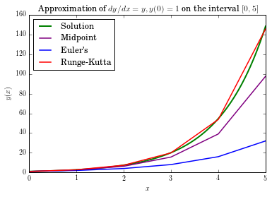

```python
t = np.linspace(x0,x_max,1000)

plt.plot(t,np.exp(t),color='green',label = 'Solution',lw=2)
plt.plot(x,ym,color='purple', label='Midpoint',lw=1.5)
plt.plot(x,y,color='blue',label='Euler\'s',lw=1.5)
plt.plot(x,yr,color='red',label='Runge-Kutta',lw=1.5)

plt.legend(loc=2)
plt.title('Approximation of $dy/dx = y, y(0)=1$ on the interval $[0,5]$')
plt.xlabel('$x$')
plt.ylabel('$y(x)$')
plt.show()
```

As can be seen, even for a large step-size ($h = 1$), the Runge-Kutta method is extremely accurate. The main source of error is the linear interpolation between points; there is very little accumulation of error compared to the other two methods.

Let's test these three methods for different step sizes, and compare RMS error

```python
#hs = np.array(np.linspace(1,.001,2000))
ns = np.arange(5,500,1)

rms_m = np.zeros(ns.size)
rms_e = np.zeros(ns.size)
rms_r = np.zeros(ns.size)

j = 0

for n in ns:

    x0 = 0
    y0 = exp(0)
    x_max = 5
    #n = int(ceil((x_max - x0)/h))
    h = (x_max*1.-x0*1.)/n

    x = np.zeros(n)
    y = np.zeros(n)
    ym = np.zeros(n)
    yr = np.zeros(n)
    x[0] = x0
    y[0] = y0
    ym[0] = y0
    yr[0] = y0

    i = 1

    while i < n:
        ym[i] = midpoint_method(f, x[i-1], ym[i-1], h)
        y[i] = eulers_method(f, x[i-1], y[i-1], h)
        yr[i] = runge_kutta(f, x[i-1], yr[i-1], h)
        x[i] = x[i-1] + h
        i = i + 1

    rms_m[j] = (np.sum((ym - np.exp(x))**2)/ym.size)**(1./2.)
    rms_e[j] = (np.sum((y - np.exp(x))**2)/y.size)**(1./2.)
    rms_r[j] = (np.sum((yr - np.exp(x))**2)/yr.size)**(1./2.)
    j = j + 1
```

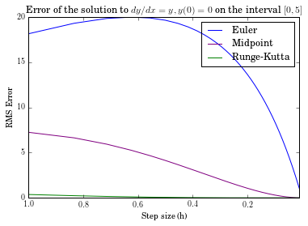

```python
hs = (x_max-x0)*np.ones(ns.size)/ns
plt.plot(hs,rms_e,color='blue',label='Euler')
plt.plot(hs,rms_m,color='purple',label='Midpoint')
plt.plot(hs,rms_r,color='green',label='Runge-Kutta')
plt.legend(loc=1)
plt.xlabel('Step size (h)')
plt.ylabel('RMS Error')
plt.xlim(np.max(hs),np.min(hs))
plt.title('Error of the solution to $dy/dx = y, y(0) = 0$ on the interval $[0,5]$')
plt.show()
```

Above is a plot of the error. Let's zoom in on the Midpoint method and Runge-Kutta

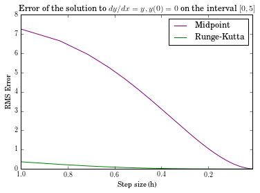

```python
hs = (x_max-x0)*np.ones(ns.size)/ns
plt.plot(hs,rms_m,color='purple',label='Midpoint')
plt.plot(hs,rms_r,color='green',label='Runge-Kutta')
plt.legend(loc=1)
plt.xlabel('Step size (h)')
plt.ylabel('RMS Error')
plt.xlim(np.max(hs),np.min(hs))
plt.title('Error of the solution to $dy/dx = y, y(0) = 0$ on the interval $[0,5]$')
plt.show()
```

As we can clearly see, the midpoint method is a huge improvement over Euler's methods, and Runge-Kutta is a huge improvement over the Midpoint method.

## Second Order ODEs

Let's extend our methods to solving ODEs in the form:

$$y'' = f(x, y(x), y'(x)), y(0) = y_0, y'(0)= y'_0$$

We can tackel this by re-writing it as a system of two first-order ODEs:

$$ \begin{align} d(y')/dx &= f(x, y(x), y'(x))\\ dy/dx &= y' \end{align} $$

For example, Euler's method would look like:

$$ \begin{align} y'(x + h) &\approx y'(x) + h * f(x, y(x), y'(x))\\ y(x+h) &\approx y(x) + h*y'(x) \end{align} $$

```python
def euler_2nd(f, x, y, yp, h):
    """
    Approximates the solution to y'' = f(x, y, yp) using an extended Euler's method

    Return is a 2-tuple containing an approximation of (y'(x+h), y(x+h))
    """

    return (y + h*yp,yp + h*f(x, y, yp))
```

## Second Order ODE example

Let's approximate te solution to $y'' = -y, y(0) = 1, y'(0)=0$

```python
def f(x,y, yp): return -1*y

h = .05
x0 = 0
y0 = 1
yp0 = 0
x_max = 10
n = ceil((x_max - x0)/h) + 1

x = np.zeros(n)
y = np.zeros(n)
yp = np.zeros(n)

x[0] = x0
y[0] = y0
yp[0] = yp0

i = 0

while x[i] < x_max:
    i = i + 1

    (y[i], yp[i]) = euler_2nd(f, x[i-1], y[i-1], yp[i-1], h)


    x[i] = x[i-1] + h
```

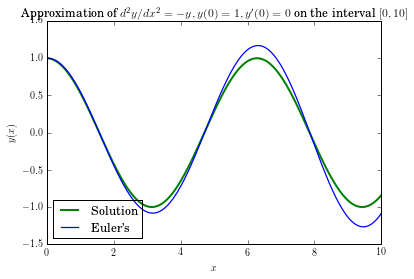

```python
t = np.linspace(x0,x_max,1000)

plt.plot(t,np.cos(t),color='green',label = 'Solution',lw=2)
plt.plot(x,y,color='blue',label='Euler\'s',lw=1.25)

plt.legend(loc=3)
plt.title('Approximation of $d^2y/dx^2 = -y, y(0)=1, y\'(0)=0$ on the interval $[0,10]$')
plt.xlabel('$x$')
plt.ylabel('$y(x)$')
plt.xlim(x0,x_max)

plt.show()
```

Euler's method for this 2nd-Order ODE start out fine, but diverges, even with a very low step size. Notice that actual solution is bounded between $-1$ and $1$ whereas the approximation is not boudned. This is a common error in physical applications such as orbital motion where the numerical solution seems to violate conservation of energy! Once again error builds up over time, despite a low step size. We need a better method.

We need a better method. Let's start by extedning the Midpoint Method to second order ODEs.

## Midpoint Method for Second Order ODEs

Consider $d^2y/dx^2 = f(x, y(x), y'(x))$. Let $u = (y(x), y'(x))$. We then have $du/dx = (y'(x), y''(x)) = (y'(x), f(x,u))$

From this notation we can first re-derive Euler's Method for 2nd-order equations without handwaving. Namely $u(x+h)\approx u(x)+h*u'(x)$ and thus $(y(x+h), y'(x+h)) \approx (y(x) + h * y'(x), y'(x) + h*y''(x)) = (y(x) + h * y'(x), y'(x) + h*f(x,y(x),y'(x))$ which was previously given without explanation, and broken up by components.

Now let's use this notation to find the midpoint formula for 2nd order equations. We have:

$$ \begin{align} u(x+h) &\approx u(x) + h*u'(x+h/2)\\ (y(x+h), y'(x+h)) &\approx (y(x), y'(x)) + h*(y'(x+h/2), y''(x + h/2))\\ &\therefore\\ y(x+h) &\approx y(x) + h*y'(x+h/2)\\ y'(x+h) &\approx y'(x) + h*f(x+h/2, y(x+h/2), y'(x+h/2))\\ &\therefore\\ y(x+h) &\approx y(x) + h*(y'(x) + h/2 * f(x, y(x), y'(x)))\\ y'(x+h) &\approx y'(x) + h * f(x+h/2, y(x) + h/2*y'(x),y'(x) + h/2 * f(x, y(x), y'(x))) \end{align} $$

which addmitedly looks scary but luckily Python is powerful. Let's start by implementing this.

```python
def midpoint_2nd(f, x, y, yp, h):
    """
    Approximates the solution to y'' = f(x, y, yp) using an extended midpoint method

    Return is a 2-tuple containing an approximation of (y'(x+h), y(x+h))
    """

    yn = y + h*(yp + h/2 * f(x,y,yp))
    ypn = yp + h*f(x+h/2,y+h/2*yp,yp+h/2*f(x,y,yp))

    return (yn, ypn)
```

```python
def f(x,y, yp): return -1*y

h = .21
x0 = 0
y0 = 1
yp0 = 0
x_max = 10
n = ceil((x_max - x0)/h) + 1

x = np.zeros(n)
y = np.zeros(n)
yp = np.zeros(n)
ym = np.zeros(n)
ypm = np.zeros(n)

x[0] = x0
ym[0] = y0
ypm[0] = yp0
y[0] = y0
yp[0] = yp0

i = 0

while x[i] < x_max:
    i = i + 1

    (ym[i], ypm[i]) = midpoint_2nd(f, x[i-1], ym[i-1], ypm[i-1], h)
    (y[i], yp[i]) = euler_2nd(f, x[i-1], y[i-1], yp[i-1], h)

    x[i] = x[i-1] + h
```

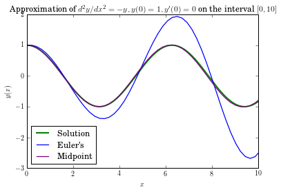

```python
t = np.linspace(x0,x_max,1000)

plt.plot(t,np.cos(t),color='green',label = 'Solution',lw=2)
plt.plot(x,y,color='blue',label='Euler\'s',lw=1.25)
plt.plot(x,ym,color='purple',label='Midpoint',lw=1.25)

plt.legend(loc=3)
plt.title('Approximation of $d^2y/dx^2 = -y, y(0)=1, y\'(0)=0$ on the interval $[0,10]$')
plt.xlabel('$x$')
plt.ylabel('$y(x)$')
plt.xlim(x0,x_max)

plt.show()
```

We can clearly see that the midpoint method is far more accurate than Euler's method. We no longer have the issue of an unbounded solution, so our method is much more suitable for real-world applications. However, imagine how powerful Runge-Kutta would be! Let's work on extending Runge-Kutta to second order differential equations.

## Runge-Kutta for Second Order ODEs

We'll start by taking the first-order Runge-Kutta and swapping the $y$'s for $u = (y,y')$:

$$ \begin{align} k_1 &= (y'(x), f(x,u(x)))\\ k_2 &= (y'(x) + h/2*k_{1}[1],f(x + h/2, u(x) + h/2 * k_1))\\ k_3 &= (y'(x) + h/2*k_{2}[1],f(x + h/2, u(x) + h/2 * k_2))\\ k_4 &= (y'(x) + h*k_{3}[1],f(x + h, u(x) + h*k_3)) \end{align} $$

and $u(x + h) \approx u(x) + h/6 * (k_1 + 2*k_2 + 2*k_3 + k_4)$

Notice the $k_i$'s are all 2-tuples now. Let's let the $+$ and $*$ operators be element-wise. Further $k_{i}[j]$ is the $j$th element of $k_i$, indexed starting at $0$. Whereas in the orignal Runge-Kutta method $k_i$ was a guess for the average $y'$ on $[x, x+h]$, $k_i$ is now a guess for the average $(y'(x), y''(x))$ on the same interval.

```python
def runge_kutta_2nd(f, x, y, yp, h):
    """
    Approximates the solution to y'' = f(x, y, yp) using an extended Runge-Kutta method

    Return is a 2-tuple containing an approximation of (y'(x+h), y(x+h))
    """

    k1 = (yp, f(x, y, yp))
    k2 = (yp + h/2*k1[1], f(x+h/2, y + h/2*k1[0], yp + h/2*k1[1]))
    k3 = (yp + h/2*k2[1], f(x+h/2, y + h/2*k2[0], yp + h/2*k2[1]))
    k4 = (yp + h*k3[1], f(x+h, y+h*k3[0], yp + h*k3[1]))

    return np.array((y,yp)) + h/6*(np.array(k1) + 2*np.array(k2) + 2*np.array(k3) + np.array(k4))
    #Casting to numpy arrays so I get element-wise addition instead of concatination
```

```python
def f(x,y, yp): return -1*y

h = .51
x0 = 0
y0 = 1
yp0 = 0
x_max = 10
n = ceil((x_max - x0)/h) + 1

x = np.zeros(n)
y = np.zeros(n)
yp = np.zeros(n)
ym = np.zeros(n)
ypm = np.zeros(n)
yr = np.zeros(n)
ypr = np.zeros(n)

x[0] = x0
ym[0] = y0
ypm[0] = yp0
y[0] = y0
yp[0] = yp0
yr[0] = y0
ypr[0] = yp0

i = 0

while x[i] < x_max:
    i = i + 1

    (ym[i], ypm[i]) = midpoint_2nd(f, x[i-1], ym[i-1], ypm[i-1], h)
    (y[i], yp[i]) = euler_2nd(f, x[i-1], y[i-1], yp[i-1], h)
    (yr[i], ypr[i]) = runge_kutta_2nd(f, x[i-1], yr[i-1], ypr[i-1], h)

    x[i] = x[i-1] + h
```

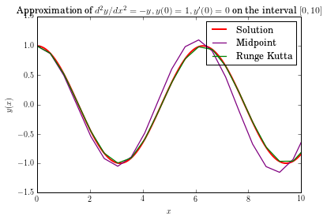

```python
t = np.linspace(x0,x_max,1000)

plt.plot(t,np.cos(t),color='red',label = 'Solution',lw=2)
#plt.plot(x,y,color='blue',label='Euler\'s',lw=1.25)
plt.plot(x,ym,color='purple',label='Midpoint',lw=1.25)
plt.plot(x,yr,color='green',label='Runge Kutta',lw=1.25)

plt.legend(loc=1)
plt.title('Approximation of $d^2y/dx^2 = -y, y(0)=1, y\'(0)=0$ on the interval $[0,10]$')
plt.xlabel('$x$')
plt.ylabel('$y(x)$')
plt.xlim(x0,x_max)

plt.show()
```

Take note that the step size on this is $10\mathrm{x}$ larger than the step size on the orignal example with Euler's method, and yet vastly more accurate.